# Taller: agentes y problemas de búsqueda

Actividad · Elegir una estrategia para un agente de inspección

## Situación

Un agente de inspección debe llegar desde `Acceso` hasta `CentroDatos`, donde se reportó una alerta. Cada fila del archivo describe una acción disponible; el costo expresa el tiempo de desplazamiento.

Antes de ejecutar una búsqueda, respondan:

| Componente | Respuesta |
| --- | --- |
| Estado del agente |  |
| Estado inicial |  |
| Acciones posibles |  |
| Resultado de una acción |  |
| Objetivo |  |
| Criterio para preferir una solución |  |

## 1. Leer y explorar los datos

```python
import sys
from pathlib import Path

import matplotlib.pyplot as plt
import networkx as nx
import pandas as pd

RAIZ_REPOSITORIO = Path.cwd().resolve().parents[1]
sys.path.insert(0, str(RAIZ_REPOSITORIO / ".tools/aima-python"))
from aima.search import Problem, breadth_first_graph_search, depth_first_graph_search, uniform_cost_search

ARISTAS = "datos/desafio_inspeccion.csv"
INICIAL = "Acceso"
OBJETIVO = "CentroDatos"

df = pd.read_csv(ARISTAS)
df.head()
```

|  | origen | destino | costo |
| --- | --- | --- | --- |
| 0 | Acceso | Control | 1 |
| 1 | Acceso | Depósito | 2 |
| 2 | Control | Archivo | 4 |
| 3 | Control | Patio | 2 |
| 4 | Depósito | Taller | 2 |

Para conocer todas las rutas simples posibles en este entorno pequeño:

```python
grafo = nx.from_pandas_edgelist(
    df,
    source="origen",
    target="destino",
    edge_attr="costo",
    create_using=nx.DiGraph,
)

caminos_posibles = list(nx.all_simple_paths(grafo, INICIAL, OBJETIVO))
pd.DataFrame({"camino posible": [" → ".join(camino) for camino in caminos_posibles]})
```

|  | camino posible |
| --- | --- |
| 0 | Acceso → Control → Archivo → CentroDatos |
| 1 | Acceso → Control → Patio → CentroDatos |
| 2 | Acceso → Control → Patio → Laboratorio → Centr... |
| 3 | Acceso → Depósito → Taller → Patio → CentroDatos |
| 4 | Acceso → Depósito → Taller → Patio → Laborator... |
| 5 | Acceso → Depósito → Taller → Laboratorio → Cen... |
| 6 | Acceso → Depósito → Archivo → CentroDatos |

1. ¿Cuáles son los caminos posibles?
2. ¿Cuál tiene menos acciones?
3. ¿Cuál tiene menor costo acumulado?
4. Si el objetivo fuera atender la alerta en el menor tiempo posible, ¿cuál de esas dos preguntas debería guiar al agente?

## 2. Representar el entorno

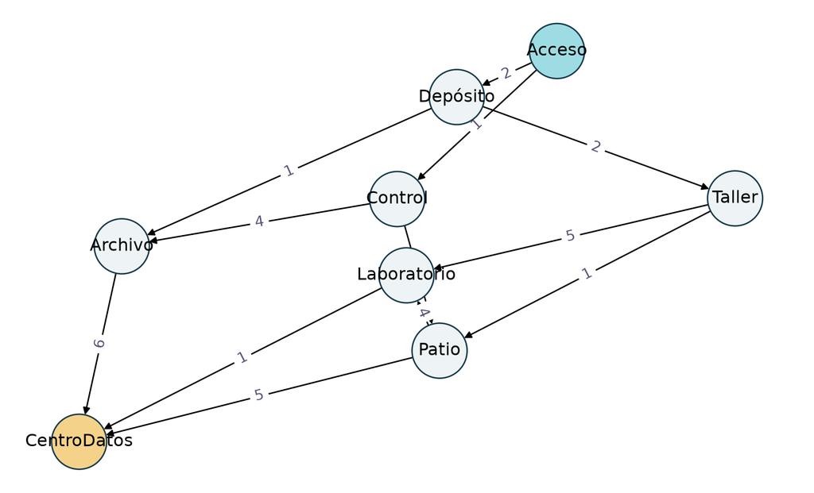

```python
posicion = nx.spring_layout(grafo, seed=21)
colores = ["#9edce3" if nodo == INICIAL else "#f4d28a" if nodo == OBJETIVO else "#eef4f5" for nodo in grafo.nodes]
plt.figure(figsize=(10, 6))
nx.draw_networkx(grafo, posicion, node_color=colores, edgecolors="#14384a", node_size=1500, arrows=True)
nx.draw_networkx_edge_labels(grafo, posicion, edge_labels=nx.get_edge_attributes(grafo, "costo"), font_color="#5d5179")
plt.axis("off")
plt.show()
```

¿La dirección de las flechas importa en este problema? Expliquen qué acción se estaría habilitando o prohibiendo si reemplazáramos el grafo dirigido por uno no dirigido.

## 3. Resolver con las búsquedas del libro

`aima-python` implementa las búsquedas; la clase siguiente sólo expresa el problema de este agente en la interfaz de Russell y Norvig.

```python
class ProblemaInspeccion(Problem):
    def __init__(self, aristas, inicial, objetivo):
        super().__init__(initial=inicial, goal=objetivo)
        self.salidas = aristas.groupby("origen")
        self.costos = {(fila.origen, fila.destino): fila.costo for fila in aristas.itertuples(index=False)}

    def actions(self, estado):
        if estado not in self.salidas.groups:
            return []
        return self.salidas.get_group(estado)["destino"].tolist()

    def result(self, estado, accion):
        return accion

    def path_cost(self, costo_acumulado, estado, accion, siguiente_estado):
        return costo_acumulado + self.costos[(estado, accion)]

problema = ProblemaInspeccion(df, INICIAL, OBJETIVO)
```

Ejecuten las estrategias y completen la interpretación, no el algoritmo.

```python
def fila(nombre, nodo):
    camino = [n.state for n in nodo.path()]
    return {"estrategia": nombre, "camino": " → ".join(camino), "pasos": nodo.depth, "costo": nodo.path_cost}

pd.DataFrame([
    fila("BFS", breadth_first_graph_search(problema)),
    fila("DFS", depth_first_graph_search(problema)),
    fila("Costo uniforme", uniform_cost_search(problema)),
])
```

|  | estrategia | camino | pasos | costo |
| --- | --- | --- | --- | --- |
| 0 | BFS | Acceso → Control → Archivo → CentroDatos | 3 | 11 |
| 1 | DFS | Acceso → Depósito → Archivo → CentroDatos | 3 | 9 |
| 2 | Costo uniforme | Acceso → Control → Patio → CentroDatos | 3 | 8 |

1. ¿Cuál es la solución con menor cantidad de acciones? ¿Qué búsqueda la encuentra?
2. ¿Cuál es la solución con menor costo? ¿Qué búsqueda la encuentra?
3. ¿Qué resultado devuelve DFS en esta corrida? ¿Por qué no conviene tomarlo como criterio de calidad general?
4. Para el agente de inspección, ¿qué estrategia elegirían y por qué?

## 4. Cambio del entorno

El pasaje `Laboratorio → CentroDatos` queda inhabilitado. Sin cambiar la definición de los estados, construyan el nuevo conjunto de datos y repitan las **dos líneas** que corresponden a la estrategia que eligieron.

```python
df_alternativo = df.loc[
    ~((df["origen"] == "Laboratorio") & (df["destino"] == "CentroDatos"))
].copy()

df_alternativo
```

|  | origen | destino | costo |
| --- | --- | --- | --- |
| 0 | Acceso | Control | 1 |
| 1 | Acceso | Depósito | 2 |
| 2 | Control | Archivo | 4 |
| 3 | Control | Patio | 2 |
| 4 | Depósito | Taller | 2 |
| 5 | Depósito | Archivo | 1 |
| 6 | Archivo | CentroDatos | 6 |
| 7 | Patio | CentroDatos | 5 |
| 8 | Taller | Patio | 1 |
| 9 | Taller | Laboratorio | 5 |
| 11 | Patio | Laboratorio | 4 |

¿Qué elemento de la formulación del problema cambió? ¿Qué elementos se mantuvieron? Si no existiera ningún camino al objetivo, ¿qué debería poder informar el agente?

## Entrega breve

Entreguen la formulación del problema, la elección razonada de una estrategia y respuestas concisas a las preguntas de análisis. No se evalúa la implementación de los algoritmos: se evalúa que puedan relacionar el problema del agente con la búsqueda seleccionada.